# Jakob Bindas CS 1675 Final Project

2024-04-12

## Final Project: Classification

This Rmd file provides my solutions to the classification portion of tasks. Those for regression related tasks are found in Bindas_Jakob_Regression.Rmd

Load in packages

```r
library(caret)
library(tidyverse)
```

Load in the data. Important response names are $\textbf{response}$ and $\textbf{outcome}$. $\textbf{response}$ is used for the regression tasks and $\textbf{outcome}$ is used for the classification tasks (event = 1, non-event = 0; popular vs less popular paints)

```r
# Mutuate the original dataframe to also contain the logit response, y
df <- readr::read_csv('paint_project_train_data-1.csv', col_names = TRUE)
df %>% head()
```

```
## # A tibble: 6 × 8
##       R     G     B Lightness Saturation   Hue response outcome
##   <dbl> <dbl> <dbl> <chr>     <chr>      <dbl>    <dbl>   <dbl>
## 1   172    58    62 dark      bright         4       12       1
## 2    26    88   151 dark      bright        31       10       1
## 3   172    94    58 dark      bright         8       16       1
## 4    28    87   152 dark      bright        32       10       0
## 5   170    66    58 dark      bright         5       11       0
## 6   175    89    65 dark      bright         6       16       0
```

## A. Linear Models

```r
# Intercept only
mod_01 <- lm(outcome ~ 1, data=df)

# Categorical only - linear additive
mod_02 <- lm(outcome ~ Lightness + Saturation, data=df)

# Continuous only - linear additive
mod_03 <- lm(outcome ~ R + G + B + Hue, data=df)

# Continuous only - linear additive
mod_04 <- lm(outcome ~ R + G + B + Hue + Lightness + Saturation, data=df)

# Interation of categorical with all continuous inputs
mod_05 <- lm(outcome ~ Lightness : (R + G + B + Hue) + Saturation : (R + G + B + Hue), data=df)

# Add categorical inputs to all main effect and all parwise interactions of continuous inputs
mod_06 <- lm(outcome ~ Lightness + Saturation + (R * G * B * Hue), data=df)

# Interaction of categorical inputs with all main effect and interactions of continuous inputs
mod_07 <- lm(outcome ~ Lightness : (R * G * B * Hue) + Saturation : (R * G * B * Hue), data=df)

# Nonlinear basis function - quadratic features of continuous inputs
mod_08 <- lm(outcome ~ I(R^2) + I(G^2) + I(B^2) + I(Hue^2), data=df)

# Interactions of basis functions with other basis functions - interactions of quadratic features
mod_09 <- lm(outcome ~ I(R^2) * I(G^2) * I(B^2) * I(Hue^2), data=df)

# Interactions of basis functions with categorical inputs
mod_10 <- lm(outcome ~ Lightness : (I(R^2) + I(G^2) + I(B^2) + I(Hue^2)) + Saturation : (I(R^2) + I(G^2) + I(B^2) + I(Hue^2)), data=df)
```

```r
# Analyze model performance using broom::glance
model_performance <- function(model){
  broom::glance(model)
}
```

```r
models <- list(mod_01, mod_02, mod_03, mod_04, mod_05, mod_06, mod_07, mod_08, mod_09, mod_10)
model_numbers <- c(1, 2, 3, 4, 5, 6, 7, 8, 9, 10)

lm_results <- purrr::map_dfr(models, model_performance) %>%
  mutate(
    model_number = model_numbers
  ) %>%
  select(
    model_number, AIC, BIC
  )
lm_results
```

```
## # A tibble: 10 × 3
##    model_number   AIC   BIC
##           <dbl> <dbl> <dbl>
##  1            1  925.  934.
##  2            2  724.  790.
##  3            3  903.  931.
##  4            4  720.  805.
##  5            5  713.  969.
##  6            6  646.  783.
##  7            7  605. 1537.
##  8            8  893.  922.
##  9            9  853.  933.
## 10           10  731.  986.
```

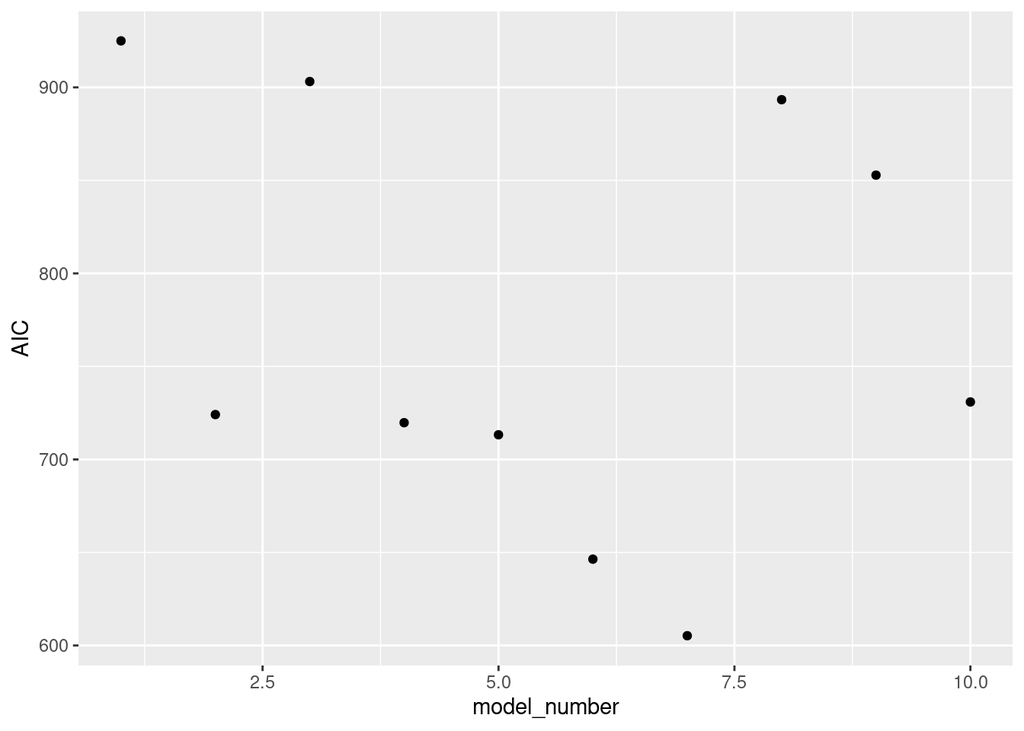

```r
# Visualize AIC and BIC
lm_results %>% ggplot(mapping=aes(x=model_number, y=AIC)) +
  geom_point()
```

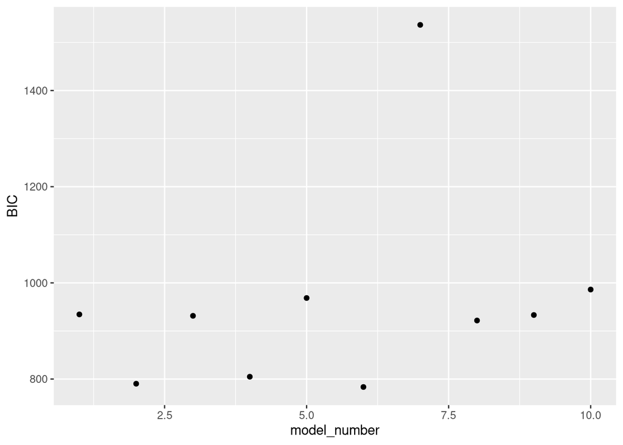

```r
lm_results %>% ggplot(mapping=aes(x=model_number, y=BIC)) +
  geom_point()
```

According to AIC, models 5, 6, 7 are the best and BIC says 2, 4, 6. I will definitely choose model 6, and choose to work with 2 and 4 since the AIC values are still on a comparable scale to BIC, while the other’s BICs are much higher. Model 6 is definitely the best.

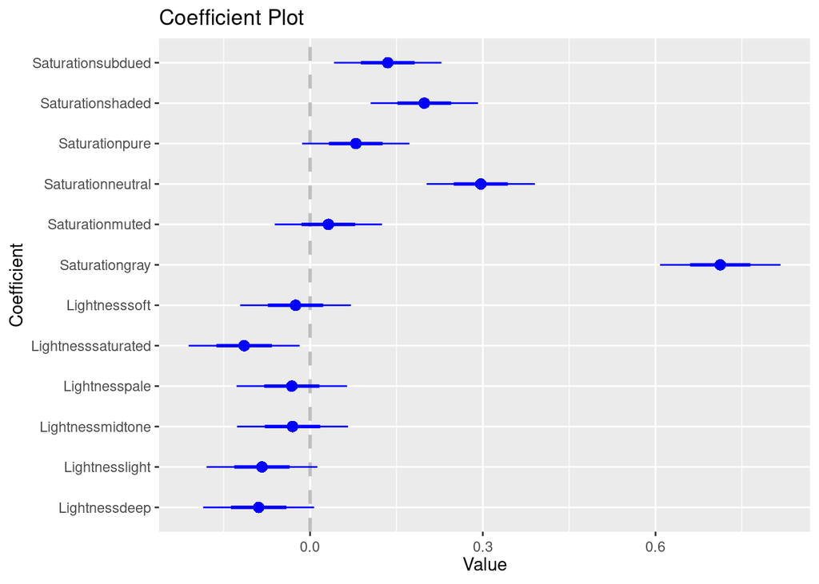

```r
# Visualize the coefficient summaries for each model
mod_02 %>%
  coefplot::coefplot(intercept=FALSE)
```

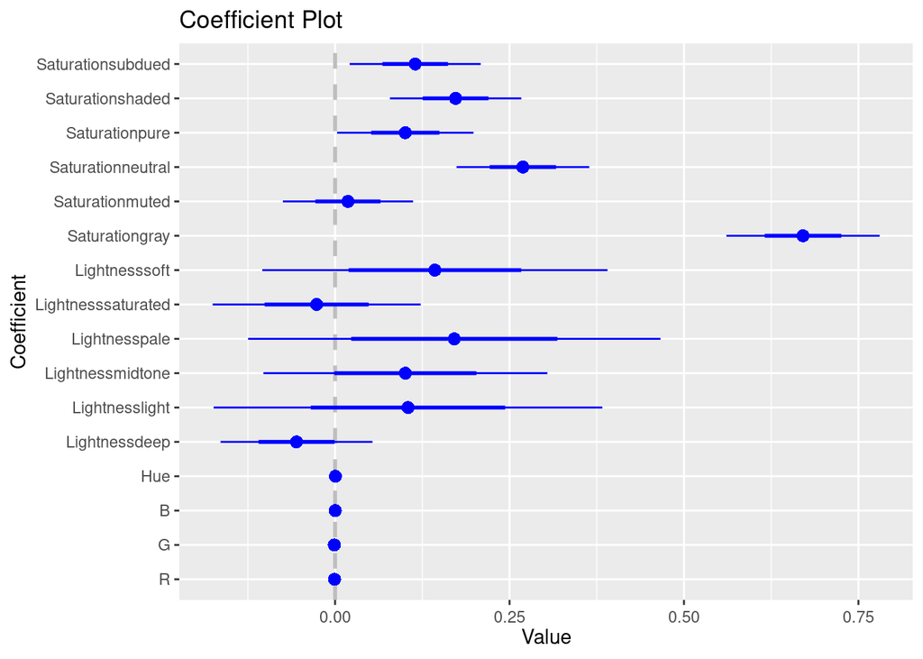

```r
mod_04 %>%
  coefplot::coefplot(intercept=FALSE)
```

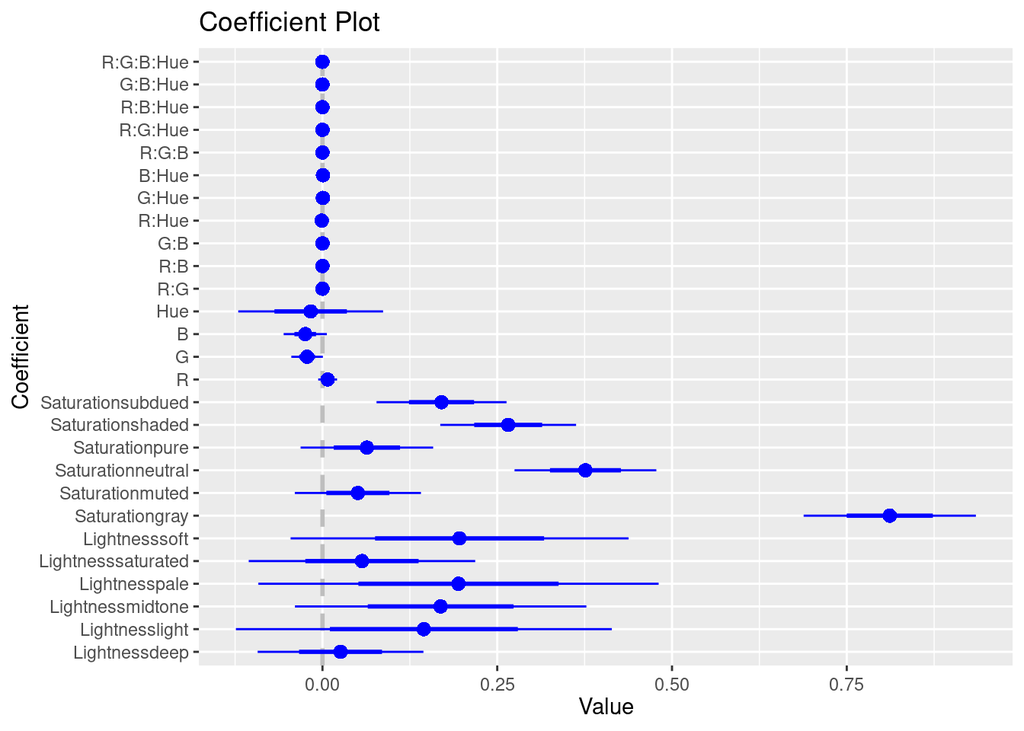

```r
mod_06 %>%
  coefplot::coefplot(intercept=FALSE)
```

Model 4 doesn’t reveal a whole lot since most of its coefficients are not significant. Model 2 reveals that Saturation holds a big effect while Lightness does not. The same goes for model 6. Saturation and Lightness appear to be the only inputs that are important to the outcome output since those are the only features that are significant.

## B. Bayesian Linear Models

I am using mod_06 as it was the best score in terms of BIC (with a relatively low AIC) and mod_02 as it emphasizes solely on the categorical inputs. I am opting for the extremely simple model to hopefully reveal more about the impact of the categorical variables on the binary outcome

I will opt to use the rstanarm approach using stan_glm

```r
library(rstanarm)
mod_02_rstan <- stan_glm(outcome ~ Lightness + Saturation,
                        data=df,
                        family='binomial',
                        seed=12345,
                        iter=3000)
mod_06_rstan <- stan_glm(outcome ~ Lightness + Saturation + (R * G * B * Hue),
                        data=df,
                        family='binomial',
                        seed=12345,
                        iter=3000)
```

We can analyze model performance here by analyzing the R^2 values for each model.

```r
get_rsquared <- function(model, model_name)
{
  tibble::tibble(
    r_squared = bayes_R2(model),
    model_name = model_name
  )
}
```

```r
r_squared_df <- purrr::map2_dfr(list(mod_02_rstan, mod_06_rstan),
                             as.character(c(2, 6)),
                             get_rsquared
                             )
```

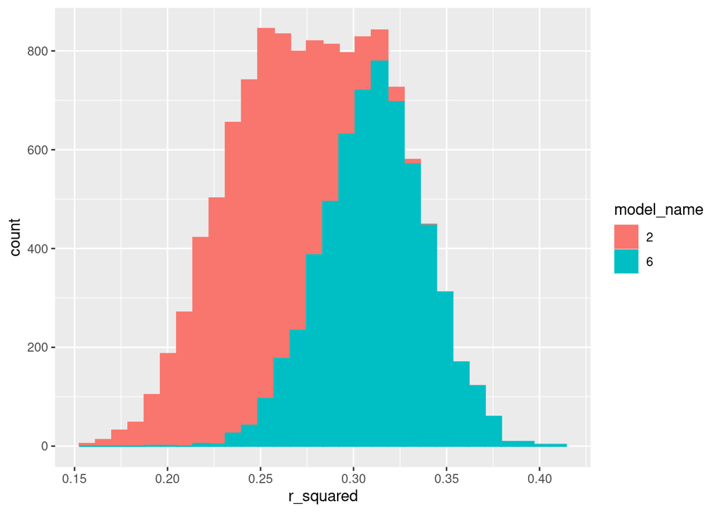

```r
r_squared_df %>%
  ggplot(mapping=aes(x=r_squared, color=model_name, fill=model_name)) +
  geom_histogram()
```

From the above plot, we can see a clear difference between rsquared value distributions. Model 6 has a higher r^2 with a tighter distribution. Note the difference between this and the regression model where there was a very strong relationship for model 6. Our best model here is again 6, but this distribution is indicative of a weak relationship.

```r
waic_mod_02 <- waic(mod_02_rstan)$waic
waic_mod_06 <- waic(mod_06_rstan)$waic
tibble::tibble(
  model = c(2, 6),
  waic = c(waic_mod_02, waic_mod_06)
)
```

```
## # A tibble: 2 × 2
##   model  waic
##   <dbl> <dbl>
## 1     2  741.
## 2     6  676.
```

Again, we see the same as illustrated by the histogram above. Model 6 has a lower WAIC score, so it is the better model.

#### Study posterior uncertainty on $\sigma$

The outputted glm model did not present a sigma parameter like it did in the regression section using lm, so I cannot compare.

## C. Linear Models Predictions

```r
# Define the visualization grid: primary variable is G (the variable with the strongest impact from the exploration) and Saturation as the secondary
viz_grid <- expand.grid(R = mean(df$R),
                        G = seq(50, 150, by=1),
                        B = mean(df$B),
                        Hue = mean(df$Hue),
                        Lightness = 'saturated',
                        Saturation = unique(df$Saturation)) %>%
  as.data.frame() %>% tibble::as_tibble()
```

```r
# Function defined previously in homeworks
tidy_predict <- function(mod, xnew)
{
  pred_df <- predict(mod, xnew, interval = "confidence") %>%
    as.data.frame() %>% tibble::as_tibble() %>%
    dplyr::select(pred = fit, ci_lwr = lwr, ci_upr = upr) %>%
    bind_cols(predict(mod, xnew, interval = 'prediction') %>%
                as.data.frame() %>% tibble::as_tibble() %>%
                dplyr::select(pred_lwr = lwr, pred_upr = upr))

  xnew %>% bind_cols(pred_df)
}
```

```r
# Run prediction on non-Bayesian lm() results (this is what I am more familiar working with)
pred_lm_02 <- tidy_predict(mod_02, viz_grid)
pred_lm_06 <- tidy_predict(mod_06, viz_grid)
```

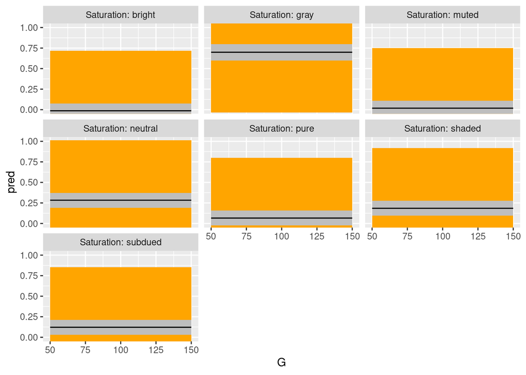

```r
# Visualize the predicted lm 02
pred_lm_02 %>%
  ggplot(mapping=aes(x=G)) +
  geom_ribbon(mapping=aes(ymin=pred_lwr, ymax=pred_upr), fill='orange') +
  geom_ribbon(mapping=aes(ymin=ci_lwr, ymax=ci_upr), fill='grey') +
  geom_line(mapping=aes(y=pred)) +
  coord_cartesian(ylim=c(0, 1)) +
  facet_wrap(~Saturation, labeller='label_both')
```

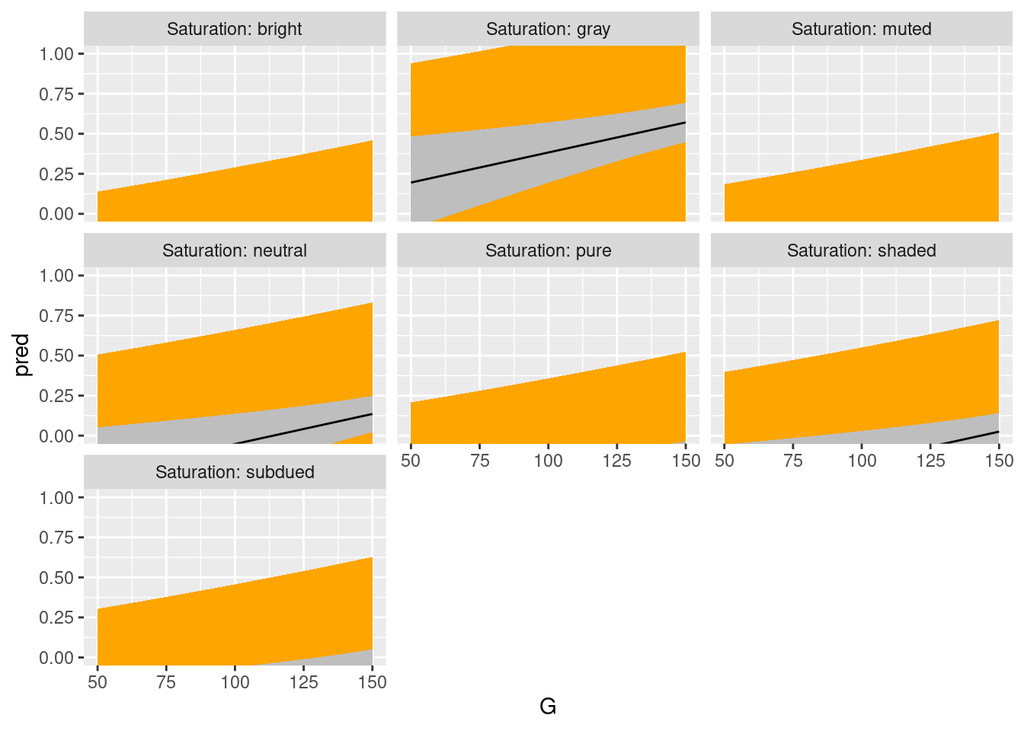

```r
# Visualize the predicted lm 06
pred_lm_06 %>%
  ggplot(mapping=aes(x=G)) +
  geom_ribbon(mapping=aes(ymin=pred_lwr, ymax=pred_upr), fill='orange') +
  geom_ribbon(mapping=aes(ymin=ci_lwr, ymax=ci_upr), fill='grey') +
  geom_line(mapping=aes(y=pred)) +
  coord_cartesian(ylim=c(0, 1)) +
  facet_wrap(~Saturation, labeller='label_both')
```

The predictive trends are not good for model 6, except for the Saturation = gray facet, where it seems to start following a trend where we would expect based on the exploration section. Model 2 seems to be only showing a constant value for each facet. The predictive trends are not consistent between the two models selected.

## D. Train/Tune with Resampling

### Linear Models

```r
my_ctrl <- trainControl(method = "repeatedcv",
                        number = 10,
                        repeats = 3
                        )

my_metric <- 'Accuracy'
```

```r
# Need to alter the dataframe to give event vs non-event data
df_caret <- df %>%
  mutate(outcome = ifelse(outcome == 1, 'event', 'non_event')) %>%
  mutate(outcome = factor(outcome, levels = c("event", "non_event"))) %>%
  select(R,G,B,Hue,Lightness,Saturation,outcome)

df_caret %>% glimpse()
```

```
## Rows: 835
## Columns: 7
## $ R          <dbl> 172, 26, 172, 28, 170, 175, 90, 194, 171, 122, 0, 88, 144, …
## $ G          <dbl> 58, 88, 94, 87, 66, 89, 78, 106, 68, 151, 121, 140, 82, 163…
## $ B          <dbl> 62, 151, 58, 152, 58, 65, 136, 53, 107, 59, 88, 58, 132, 50…
## $ Hue        <dbl> 4, 31, 8, 32, 5, 6, 34, 10, 1, 21, 24, 22, 36, 16, 26, 12, …
## $ Lightness  <chr> "dark", "dark", "dark", "dark", "dark", "dark", "dark", "da…
## $ Saturation <chr> "bright", "bright", "bright", "bright", "bright", "bright",…
## $ outcome    <fct> event, event, event, non_event, non_event, non_event, non_e…
```

```r
set.seed(12345)
lm_default_3 <- train(outcome ~ R + G + B + Hue + Lightness + Saturation,
                   data=df_caret,
                   method='glm',
                   metric=my_metric,
                   trControl=my_ctrl
                   )
```

```r
set.seed(12345)
# NOTE: THIS MEETS A REQUIREMENT FOR LINEAR MODELS. IT IS ONE OF THE ONES SELECTED IN A
lm_default_1 <- train(outcome ~ Lightness + Saturation + (R * G * B * Hue),
                   data=df_caret,
                   method='glm',
                   metric=my_metric,
                   trControl=my_ctrl
                   )
```

```r
set.seed(12345)
lm_default_2 <- train(outcome ~ Lightness + Saturation,
                   data=df_caret,
                   method='glm',
                   metric=my_metric,
                   trControl=my_ctrl
                   )
```

### Elastic Net

```r
set.seed(12345)
enet_default_1 <- train(outcome ~ Lightness + Saturation + (R * G * B * Hue),
                        data=df_caret,
                        method='glmnet',
                        metric=my_metric,
                        preprocess=c('center', 'scale'),
                        trControl=my_ctrl)
enet_default_1
```

```
## glmnet
##
## 835 samples
##   6 predictor
##   2 classes: 'event', 'non_event'
##
## No pre-processing
## Resampling: Cross-Validated (10 fold, repeated 3 times)
## Summary of sample sizes: 751, 751, 751, 752, 752, 752, ...
## Resampling results across tuning parameters:
##
##   alpha  lambda        Accuracy   Kappa
##   0.10   0.0003523518  0.8219784  0.3909101
##   0.10   0.0035235183  0.8227720  0.3765382
##   0.10   0.0352351830  0.8227577  0.3692077
##   0.55   0.0003523518  0.8199608  0.3880133
##   0.55   0.0035235183  0.8243689  0.3802979
##   0.55   0.0352351830  0.8227577  0.3692077
##   1.00   0.0003523518  0.8147686  0.3794964
##   1.00   0.0035235183  0.8247705  0.3804827
##   1.00   0.0352351830  0.8227577  0.3692077
##
## Accuracy was used to select the optimal model using the largest value.
## The final values used for the model were alpha = 1 and lambda = 0.003523518.
```

```r
enet_grid_1 <- expand.grid(alpha=seq(0.1, 1.0, by=0.1),
                           lambda=exp(seq(log(min(enet_default_1$results$lambda)),
                                  log(max(enet_default_1$results$lambda)),
                                  length.out=25))
)
```

```r
set.seed(12345)
enet_tune_1 <- train(outcome ~ Lightness + Saturation + (R * G * B * Hue),
                     data=df_caret,
                     method='glmnet',
                     metric=my_metric,
                     tuneGrid=enet_grid_1,
                     preprocess=c('center', 'scale'),
                     trControl=my_ctrl)
```

```r
enet_tune_1$bestTune
```

```
##    alpha     lambda
## 92   0.4 0.00759119
```

```r
set.seed(12345)
enet_default_2 <- train(outcome ~ Lightness + Saturation,
                   data=df_caret,
                   method='glmnet',
                   metric=my_metric,
                   trControl=my_ctrl
                   )
enet_default_2
```

```
## glmnet
##
## 835 samples
##   2 predictor
##   2 classes: 'event', 'non_event'
##
## No pre-processing
## Resampling: Cross-Validated (10 fold, repeated 3 times)
## Summary of sample sizes: 751, 751, 751, 752, 752, 752, ...
## Resampling results across tuning parameters:
##
##   alpha  lambda        Accuracy   Kappa
##   0.10   0.0003523518  0.8227577  0.3692077
##   0.10   0.0035235183  0.8227577  0.3692077
##   0.10   0.0352351830  0.8227577  0.3692077
##   0.55   0.0003523518  0.8227577  0.3692077
##   0.55   0.0035235183  0.8227577  0.3692077
##   0.55   0.0352351830  0.8227577  0.3692077
##   1.00   0.0003523518  0.8227577  0.3692077
##   1.00   0.0035235183  0.8227577  0.3692077
##   1.00   0.0352351830  0.8227577  0.3692077
##
## Accuracy was used to select the optimal model using the largest value.
## The final values used for the model were alpha = 0.1 and lambda = 0.03523518.
```

```r
enet_grid_2 <- expand.grid(alpha=seq(0.1, 1.0, by=0.1),
                           lambda=exp(seq(log(min(enet_default_2$results$lambda)),
                                  log(max(enet_default_2$results$lambda)),
                                  length.out=25))
)
```

```r
set.seed(12345)
enet_tune_2 <- train(outcome ~ Lightness + Saturation,
                     data=df_caret,
                     method='glmnet',
                     metric=my_metric,
                     tuneGrid=enet_grid_2,
                     preprocess=c('center', 'scale'),
                     trControl=my_ctrl)
```

```r
enet_tune_2$bestTune
```

```
##    alpha     lambda
## 25   0.1 0.03523518
```

```r
set.seed(12345)
enet_default_3 <- train(outcome ~ R + G + B + Hue + Lightness + Saturation,
                   data=df_caret,
                   method='glmnet',
                   metric=my_metric,
                   trControl=my_ctrl
                   )
enet_default_3
```

```
## glmnet
##
## 835 samples
##   6 predictor
##   2 classes: 'event', 'non_event'
##
## No pre-processing
## Resampling: Cross-Validated (10 fold, repeated 3 times)
## Summary of sample sizes: 751, 751, 751, 752, 752, 752, ...
## Resampling results across tuning parameters:
##
##   alpha  lambda        Accuracy   Kappa
##   0.10   0.0003523518  0.8199751  0.3702640
##   0.10   0.0035235183  0.8207736  0.3712083
##   0.10   0.0352351830  0.8227577  0.3692077
##   0.55   0.0003523518  0.8199751  0.3702640
##   0.55   0.0035235183  0.8215768  0.3730268
##   0.55   0.0352351830  0.8227577  0.3692077
##   1.00   0.0003523518  0.8207736  0.3720414
##   1.00   0.0035235183  0.8215768  0.3707283
##   1.00   0.0352351830  0.8227577  0.3692077
##
## Accuracy was used to select the optimal model using the largest value.
## The final values used for the model were alpha = 0.1 and lambda = 0.03523518.
```

```r
enet_grid_3 <- expand.grid(alpha=seq(0.1, 1.0, by=0.1),
                           lambda=exp(seq(log(min(enet_default_3$results$lambda)),
                                  log(max(enet_default_3$results$lambda)),
                                  length.out=25))
)
```

```r
set.seed(12345)
enet_tune_3 <- train(outcome ~ R + G + B + Lightness + Saturation,
                     data=df_caret,
                     method='glmnet',
                     metric=my_metric,
                     tuneGrid=enet_grid_3,
                     preprocess=c('center', 'scale'),
                     trControl=my_ctrl)
```

```r
enet_tune_3$bestTune
```

```
##    alpha      lambda
## 93   0.4 0.009196937
```

### Neural Network

```r
set.seed(12345)
nnet_default_1 <- train(outcome ~ Lightness + Saturation + (R * G * B * Hue),
                   data=df_caret,
                   method='nnet',
                   metric=my_metric,
                   trControl=my_ctrl,
                   trace=FALSE
                   )

nnet_default_1
```

```
## Neural Network
##
## 835 samples
##   6 predictor
##   2 classes: 'event', 'non_event'
##
## No pre-processing
## Resampling: Cross-Validated (10 fold, repeated 3 times)
## Summary of sample sizes: 751, 751, 751, 752, 752, 752, ...
## Resampling results across tuning parameters:
##
##   size  decay  Accuracy   Kappa
##   1     0e+00  0.7712565   0.000000000
##   1     1e-04  0.7712565   0.000000000
##   1     1e-01  0.7712565   0.000000000
##   3     0e+00  0.7712565   0.000000000
##   3     1e-04  0.7712565   0.000000000
##   3     1e-01  0.7720597   0.010320738
##   5     0e+00  0.7712565   0.000000000
##   5     1e-04  0.7712565   0.000000000
##   5     1e-01  0.7708596  -0.000771417
##
## Accuracy was used to select the optimal model using the largest value.
## The final values used for the model were size = 3 and decay = 0.1.
```

```r
set.seed(12345)
nnet_default_2 <- train(outcome ~ Lightness + Saturation,
                   data=df_caret,
                   method='nnet',
                   metric=my_metric,
                   trControl=my_ctrl,
                   trace=FALSE
                   )

nnet_default_2
```

```
## Neural Network
##
## 835 samples
##   2 predictor
##   2 classes: 'event', 'non_event'
##
## No pre-processing
## Resampling: Cross-Validated (10 fold, repeated 3 times)
## Summary of sample sizes: 751, 751, 751, 752, 752, 752, ...
## Resampling results across tuning parameters:
##
##   size  decay  Accuracy   Kappa
##   1     0e+00  0.8171735  0.3376447
##   1     1e-04  0.8227577  0.3692077
##   1     1e-01  0.8227577  0.3692077
##   3     0e+00  0.8127653  0.3287610
##   3     1e-04  0.8191719  0.3638760
##   3     1e-01  0.8227577  0.3692077
##   5     0e+00  0.8151654  0.3529175
##   5     1e-04  0.8163702  0.3555116
##   5     1e-01  0.8227577  0.3692077
##
## Accuracy was used to select the optimal model using the largest value.
## The final values used for the model were size = 1 and decay = 0.1.
```

```r
set.seed(12345)
nnet_default_3 <- train(outcome ~ R + G + B + Lightness + Saturation,
                   data=df_caret,
                   method='nnet',
                   metric=my_metric,
                   trControl=my_ctrl,
                   trace=FALSE
                   )

nnet_default_3
```

```
## Neural Network
##
## 835 samples
##   5 predictor
##   2 classes: 'event', 'non_event'
##
## No pre-processing
## Resampling: Cross-Validated (10 fold, repeated 3 times)
## Summary of sample sizes: 751, 751, 751, 752, 752, 752, ...
## Resampling results across tuning parameters:
##
##   size  decay  Accuracy   Kappa
##   1     0e+00  0.7712565   0.000000000
##   1     1e-04  0.7700660  -0.002191465
##   1     1e-01  0.7975999   0.200482032
##   3     0e+00  0.7728438   0.028109981
##   3     1e-04  0.7724661   0.019015372
##   3     1e-01  0.8175416   0.393267031
##   5     0e+00  0.7668101   0.059271127
##   5     1e-04  0.7751960   0.051702255
##   5     1e-01  0.8363310   0.492684469
##
## Accuracy was used to select the optimal model using the largest value.
## The final values used for the model were size = 5 and decay = 0.1.
```

```r
# Can use the same grid for the three nnets
nnet_grid <- expand.grid(
  size=c(1, 2, 3, 4, 5),
  decay=exp(seq(-6, 0, length.out=7))
)
```

```r
set.seed(12345)
nnet_tune_1 <- train(outcome ~ Lightness + Saturation + (R * G * B * Hue),
                     data=df_caret,
                     method='nnet',
                     metric=my_metric,
                     tuneGrid=nnet_grid,
                     preprocess=c('center', 'scale'),
                     trControl=my_ctrl,
                     trace=FALSE)

nnet_tune_1$bestTune
```

```
##    size decay
## 28    4     1
```

```r
set.seed(12345)
nnet_tune_2 <- train(outcome ~ Lightness + Saturation,
                     data=df_caret,
                     method='nnet',
                     metric=my_metric,
                     tuneGrid=nnet_grid,
                     preprocess=c('center', 'scale'),
                     trControl=my_ctrl,
                     trace=FALSE)

nnet_tune_2$bestTune
```

```
##   size     decay
## 6    1 0.3678794
```

```r
set.seed(12345)
nnet_tune_3 <- train(outcome ~ R + G + B + Lightness + Saturation,
                     data=df_caret,
                     method='nnet',
                     metric=my_metric,
                     tuneGrid=nnet_grid,
                     preprocess=c('center', 'scale'),
                     trControl=my_ctrl,
                     trace=FALSE)

nnet_tune_3$bestTune
```

```
##    size     decay
## 27    4 0.3678794
```

### Random Forest

```r
set.seed(12345)
rf_default_1 <- train(outcome ~ Lightness + Saturation + (R * G * B * Hue),
                     data=df_caret,
                     method='rf',
                     metric=my_metric,
                     trControl=my_ctrl,
                     importance=TRUE)

rf_default_1
```

```
## Random Forest
##
## 835 samples
##   6 predictor
##   2 classes: 'event', 'non_event'
##
## No pre-processing
## Resampling: Cross-Validated (10 fold, repeated 3 times)
## Summary of sample sizes: 751, 751, 751, 752, 752, 752, ...
## Resampling results across tuning parameters:
##
##   mtry  Accuracy   Kappa
##    2    0.8415089  0.4649889
##   14    0.8510662  0.5341424
##   27    0.8550488  0.5515606
##
## Accuracy was used to select the optimal model using the largest value.
## The final value used for the model was mtry = 27.
```

```r
set.seed(12345)
rf_default_2 <- train(outcome ~ Lightness + Saturation,
                     data=df_caret,
                     method='rf',
                     metric=my_metric,
                     trControl=my_ctrl,
                     importance=TRUE)

rf_default_2
```

```
## Random Forest
##
## 835 samples
##   2 predictor
##   2 classes: 'event', 'non_event'
##
## No pre-processing
## Resampling: Cross-Validated (10 fold, repeated 3 times)
## Summary of sample sizes: 751, 751, 751, 752, 752, 752, ...
## Resampling results across tuning parameters:
##
##   mtry  Accuracy   Kappa
##    2    0.8227577  0.3692077
##    7    0.8183592  0.3616600
##   12    0.8143813  0.3537077
##
## Accuracy was used to select the optimal model using the largest value.
## The final value used for the model was mtry = 2.
```

```r
set.seed(12345)
rf_default_3 <- train(outcome ~ R + G + B + Hue + Lightness + Saturation,
                     data=df_caret,
                     method='rf',
                     metric=my_metric,
                     trControl=my_ctrl,
                     importance=TRUE)

rf_default_3
```

```
## Random Forest
##
## 835 samples
##   6 predictor
##   2 classes: 'event', 'non_event'
##
## No pre-processing
## Resampling: Cross-Validated (10 fold, repeated 3 times)
## Summary of sample sizes: 751, 751, 751, 752, 752, 752, ...
## Resampling results across tuning parameters:
##
##   mtry  Accuracy   Kappa
##    2    0.8227434  0.3594928
##    9    0.8654905  0.5853144
##   16    0.8647064  0.5849218
##
## Accuracy was used to select the optimal model using the largest value.
## The final value used for the model was mtry = 9.
```

### Gradient Boosted Tree

```r
set.seed(12345)
xgbTree_default_1 <- train(outcome ~ Lightness + Saturation + (R * G * B * Hue),
                     data=df_caret,
                     method='xgbTree',
                     metric=my_metric,
                     trControl=my_ctrl,
                     verbosity=0,
                     nthread=1)

xgbTree_default_1$bestTune
```

```
##    nrounds max_depth eta gamma colsample_bytree min_child_weight subsample
## 34      50         2 0.3     0              0.8                1         1
```

```r
set.seed(12345)
xgbTree_default_2 <- train(outcome ~ Lightness + Saturation,
                     data=df_caret,
                     method='xgbTree',
                     metric=my_metric,
                     trControl=my_ctrl,
                     verbosity=0,
                     nthread=1)

xgbTree_default_2$bestTune
```

```
##   nrounds max_depth eta gamma colsample_bytree min_child_weight subsample
## 1      50         1 0.3     0              0.6                1       0.5
```

```r
set.seed(12345)
xgbTree_default_3 <- train(outcome ~ Lightness + Saturation + R + G + B + Hue,
                     data=df_caret,
                     method='xgbTree',
                     metric=my_metric,
                     trControl=my_ctrl,
                     verbosity=0,
                     nthread=1)

xgbTree_default_3$bestTune
```

```
##    nrounds max_depth eta gamma colsample_bytree min_child_weight subsample
## 52      50         3 0.3     0              0.8                1         1
```

```r
xgbTree_grid_1 <- expand.grid(nrounds = c(75, 150, 225),
                              max_depth=c(2, 3, 4, 5, 6),
                              eta=c(0.5*xgbTree_default_1$bestTune$eta,
                                    xgbTree_default_1$bestTune$eta,
                                    1.5*xgbTree_default_1$bestTune$eta),
                              gamma=xgbTree_default_1$bestTune$gamma,
                              colsample_bytree=xgbTree_default_1$bestTune$colsample_bytree,
                              min_child_weight=xgbTree_default_1$bestTune$min_child_weight,
                              subsample=xgbTree_default_1$bestTune$subsample)

xgbTree_grid_2 <- expand.grid(nrounds = c(75, 150, 225),
                              max_depth=c(2, 3, 4, 5, 6),
                              eta=c(0.5*xgbTree_default_2$bestTune$eta,
                                    xgbTree_default_2$bestTune$eta,
                                    1.5*xgbTree_default_2$bestTune$eta),
                              gamma=xgbTree_default_2$bestTune$gamma,
                              colsample_bytree=xgbTree_default_2$bestTune$colsample_bytree,
                              min_child_weight=xgbTree_default_2$bestTune$min_child_weight,
                              subsample=xgbTree_default_2$bestTune$subsample)

xgbTree_grid_3 <- expand.grid(nrounds = c(75, 150, 225),
                              max_depth=c(2, 3, 4, 5, 6),
                              eta=c(0.5*xgbTree_default_3$bestTune$eta,
                                    xgbTree_default_3$bestTune$eta,
                                    1.5*xgbTree_default_3$bestTune$eta),
                              gamma=xgbTree_default_3$bestTune$gamma,
                              colsample_bytree=xgbTree_default_3$bestTune$colsample_bytree,
                              min_child_weight=xgbTree_default_3$bestTune$min_child_weight,
                              subsample=xgbTree_default_3$bestTune$subsample)
```

```r
set.seed(1234)
xgbTree_tune_1 <- train(outcome ~ Lightness + Saturation + (R * G * B * Hue),
                     data=df_caret,
                     method='xgbTree',
                     metric=my_metric,
                     tuneGrid=xgbTree_grid_1,
                     trControl=my_ctrl,
                     verbosity=0,
                     nthread=1)

xgbTree_default_1$bestTune
```

```
##    nrounds max_depth eta gamma colsample_bytree min_child_weight subsample
## 34      50         2 0.3     0              0.8                1         1
```

```r
set.seed(1234)
xgbTree_tune_2 <- train(outcome ~ Lightness + Saturation,
                     data=df_caret,
                     method='xgbTree',
                     metric=my_metric,
                     tuneGrid=xgbTree_grid_2,
                     trControl=my_ctrl,
                     verbosity=0,
                     nthread=1)

xgbTree_default_2$bestTune
```

```
##   nrounds max_depth eta gamma colsample_bytree min_child_weight subsample
## 1      50         1 0.3     0              0.6                1       0.5
```

```r
set.seed(1234)
xgbTree_tune_3 <- train(outcome ~ Lightness + Saturation + R + G + B + Hue,
                     data=df_caret,
                     method='xgbTree',
                     metric=my_metric,
                     tuneGrid=xgbTree_grid_3,
                     trControl=my_ctrl,
                     verbosity=0,
                     nthread=1)

xgbTree_default_3$bestTune
```

```
##    nrounds max_depth eta gamma colsample_bytree min_child_weight subsample
## 52      50         3 0.3     0              0.8                1         1
```

### Partial Least Squares

```r
set.seed(12345)
pls_default_1 <- train(outcome ~ Lightness + Saturation + (R * G * B * Hue),
                     data=df_caret,
                     method='pls',
                     metric=my_metric,
                     preProcess=c('center', 'scale'),
                     trControl=my_ctrl)
```

```r
set.seed(12345)
pls_default_2 <- train(outcome ~ Lightness + Saturation,
                     data=df_caret,
                     method='pls',
                     metric=my_metric,
                     preProcess=c('center', 'scale'),
                     trControl=my_ctrl)
```

```r
set.seed(12345)
pls_default_3 <- train(outcome ~ R + G + B + Hue + Lightness + Saturation,
                     data=df_caret,
                     method='pls',
                     metric=my_metric,
                     preProcess=c('center', 'scale'),
                     trControl=my_ctrl)
```

```r
pls_grid <- expand.grid(ncomp=1:10)
```

```r
set.seed(12345)
pls_tune_1 <- train(outcome ~ Lightness + Saturation + (R * G * B * Hue),
                     data=df_caret,
                     method='pls',
                     metric=my_metric,
                     tuneGrid=pls_grid,
                     preProcess=c('center', 'scale'),
                     trControl=my_ctrl)
pls_tune_1
```

```
## Partial Least Squares
##
## 835 samples
##   6 predictor
##   2 classes: 'event', 'non_event'
##
## Pre-processing: centered (27), scaled (27)
## Resampling: Cross-Validated (10 fold, repeated 3 times)
## Summary of sample sizes: 751, 751, 751, 752, 752, 752, ...
## Resampling results across tuning parameters:
##
##   ncomp  Accuracy   Kappa
##    1     0.7968541  0.2231855
##    2     0.8231593  0.3711332
##    3     0.8227577  0.3692077
##    4     0.8227577  0.3692077
##    5     0.8231593  0.3726453
##    6     0.8227577  0.3692077
##    7     0.8231593  0.3720279
##    8     0.8223704  0.3757574
##    9     0.8207736  0.3704560
##   10     0.8207784  0.3712245
##
## Accuracy was used to select the optimal model using the largest value.
## The final value used for the model was ncomp = 2.
```

```r
set.seed(12345)
pls_tune_2 <- train(outcome ~ Lightness + Saturation,
                     data=df_caret,
                     method='pls',
                     metric=my_metric,
                     tuneGrid=pls_grid,
                     preProcess=c('center', 'scale'),
                     trControl=my_ctrl)
```

[output not shown]

[output cut: 160 more lines]

[output not shown]

```r
pls_tune_2
```

```
## Partial Least Squares
##
## 835 samples
##   2 predictor
##   2 classes: 'event', 'non_event'
##
## Pre-processing: centered (12), scaled (12)
## Resampling: Cross-Validated (10 fold, repeated 3 times)
## Summary of sample sizes: 751, 751, 751, 752, 752, 752, ...
## Resampling results across tuning parameters:
##
##   ncomp  Accuracy   Kappa
##    1     0.8227577  0.3692077
##    2     0.8227577  0.3692077
##    3     0.8227577  0.3692077
##    4     0.8227577  0.3692077
##    5     0.8227577  0.3692077
##    6     0.8227577  0.3692077
##    7     0.8227577  0.3692077
##    8     0.8227577  0.3692077
##    9     0.8227577  0.3692077
##   10     0.8227577  0.3692077
##
## Accuracy was used to select the optimal model using the largest value.
## The final value used for the model was ncomp = 1.
```

```r
set.seed(12345)
pls_tune_3 <- train(outcome ~ R + G + B + Hue + Lightness + Saturation,
                     data=df_caret,
                     method='pls',
                     metric=my_metric,
                     tuneGrid=pls_grid,
                     preProcess=c('center', 'scale'),
                     trControl=my_ctrl)
pls_tune_3
```

```
## Partial Least Squares
##
## 835 samples
##   6 predictor
##   2 classes: 'event', 'non_event'
##
## Pre-processing: centered (16), scaled (16)
## Resampling: Cross-Validated (10 fold, repeated 3 times)
## Summary of sample sizes: 751, 751, 751, 752, 752, 752, ...
## Resampling results across tuning parameters:
##
##   ncomp  Accuracy   Kappa
##    1     0.8227625  0.3702076
##    2     0.8227577  0.3692077
##    3     0.8227577  0.3692077
##    4     0.8227577  0.3699683
##    5     0.8227577  0.3692077
##    6     0.8227577  0.3692077
##    7     0.8227577  0.3692077
##    8     0.8227577  0.3692077
##    9     0.8227577  0.3692077
##   10     0.8227577  0.3692077
##
## Accuracy was used to select the optimal model using the largest value.
## The final value used for the model was ncomp = 1.
```

### **Gaussian Process with Radial Basis Function Kernel**

```r
set.seed(12345)
gauss_default_1 <- train(outcome ~ Lightness + Saturation + (R * G * B * Hue),
                     data=df_caret,
                     method='gaussprRadial',
                     metric=my_metric,
                     preProcess=c('center', 'scale'),
                     trControl=my_ctrl)
```

```r
set.seed(12345)
gauss_default_2 <- train(outcome ~ Lightness + Saturation,
                     data=df_caret,
                     method='gaussprRadial',
                     metric=my_metric,
                     preProcess=c('center', 'scale'),
                     trControl=my_ctrl)
```

```r
set.seed(12345)
gauss_default_3 <- train(outcome ~ R + G + B + Hue + Lightness + Saturation,
                     data=df_caret,
                     method='gaussprRadial',
                     metric=my_metric,
                     preProcess=c('center', 'scale'),
                     trControl=my_ctrl)
```

```r
gauss_grid_1 <- expand.grid(sigma=c(0.5*gauss_default_1$bestTune$sigma,
                    gauss_default_1$bestTune$sigma,
                    2*gauss_default_1$bestTune$sigma))

gauss_grid_2 <- expand.grid(sigma=c(0.5*gauss_default_2$bestTune$sigma,
                    gauss_default_2$bestTune$sigma,
                    2*gauss_default_2$bestTune$sigma))

gauss_grid_3 <- expand.grid(sigma=c(0.5*gauss_default_3$bestTune$sigma,
                    gauss_default_3$bestTune$sigma,
                    2*gauss_default_3$bestTune$sigma))
```

```r
set.seed(12345)
gauss_tune_1 <- train(outcome ~ Lightness + Saturation + (R * G * B * Hue),
                     data=df_caret,
                     method='gaussprRadial',
                     metric=my_metric,
                     tuneGrid=gauss_grid_1,
                     preProcess=c('center', 'scale'),
                     trControl=my_ctrl)
```

```r
set.seed(12345)
gauss_tune_2 <- train(outcome ~ Lightness + Saturation,
                     data=df_caret,
                     method='gaussprRadial',
                     metric=my_metric,
                     tuneGrid=gauss_grid_2,
                     preProcess=c('center', 'scale'),
                     trControl=my_ctrl)
```

```r
set.seed(12345)
gauss_tune_3 <- train(outcome ~ R + G + B + Hue + Lightness + Saturation,
                     data=df_caret,
                     method='gaussprRadial',
                     metric=my_metric,
                     tuneGrid=gauss_grid_3,
                     preProcess=c('center', 'scale'),
                     trControl=my_ctrl)
```

### Compare each model

```r
master_model_list <- resamples(list(
  lm1=lm_default_1,
  lm2=lm_default_2,
  lm3=lm_default_3,
  enet1=enet_tune_1,
  enet2=enet_tune_2,
  enet3=enet_tune_3,
  nnet1=nnet_tune_1,
  nnet2=nnet_tune_2,
  nnet3=nnet_tune_3,
  rf1=rf_default_1,
  rf2=rf_default_2,
  rf3=rf_default_3,
  xgbTree1=xgbTree_tune_1,
  xgbTree2=xgbTree_tune_2,
  xgbTree3=xgbTree_tune_3,
  pls1=pls_tune_1,
  pls2=pls_tune_2,
  pls3=pls_tune_3,
  gauss1=gauss_tune_1,
  gauss2=gauss_tune_2,
  gauss3=gauss_tune_3
))
```

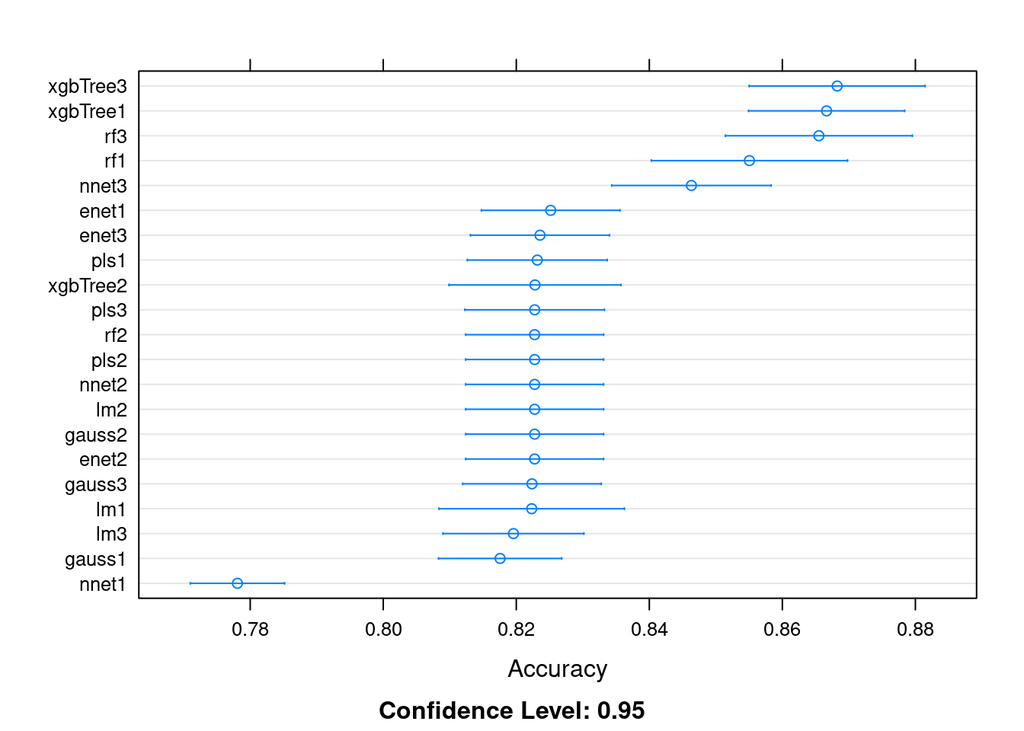

```r
dotplot(master_model_list, metric='Accuracy')
```

The model with the highest accuracy corresponds to xgbTree3, which is the gradient boosted tree model for the linear additive features of all models.

### Save Best Model

```r
xgbTree_tune_3 %>% readr::write_rds('best-models/classification-best-model-accuracy.rds')
```